# HW 3a: Penguin t-tests and correlation

MSCI 599

3/8/2021

#### Unit 3: Penguins

#### Homework # 3a t-tests and correlations

#### Skill practice: data exploration, basic statistical diagnostics, t-tests, correlations

Use the `palmerpenguins` dataset in R to answer the following questions:

Find literature values of Adelie and Chinstrap body mass. You can use the Encyclopedia of Life https://eol.org/ or find values elsewhere in the literature.

### Question 1

Are our observations of Adelie body mass significantly different from the literature?

```r
adelie = penguins %>%
  filter(species == "Adelie")
head(adelie)
```

```
## # A tibble: 6 x 8
##   species island bill_length_mm bill_depth_mm flipper_length_… body_mass_g sex
##   <fct>   <fct>           <dbl>         <dbl>            <int>       <int> <fct>
## 1 Adelie  Torge…           39.1          18.7              181        3750 male
## 2 Adelie  Torge…           39.5          17.4              186        3800 fema…
## 3 Adelie  Torge…           40.3          18                195        3250 fema…
## 4 Adelie  Torge…           NA            NA                 NA          NA <NA>
## 5 Adelie  Torge…           36.7          19.3              193        3450 fema…
## 6 Adelie  Torge…           39.3          20.6              190        3650 male
## # … with 1 more variable: year <int>
```

```r
summary(adelie)
```

```
##       species          island   bill_length_mm  bill_depth_mm
##  Adelie   :152   Biscoe   :44   Min.   :32.10   Min.   :15.50
##  Chinstrap:  0   Dream    :56   1st Qu.:36.75   1st Qu.:17.50
##  Gentoo   :  0   Torgersen:52   Median :38.80   Median :18.40
##                                 Mean   :38.79   Mean   :18.35
##                                 3rd Qu.:40.75   3rd Qu.:19.00
##                                 Max.   :46.00   Max.   :21.50
##                                 NA's   :1       NA's   :1
##  flipper_length_mm  body_mass_g       sex          year
##  Min.   :172       Min.   :2850   female:73   Min.   :2007
##  1st Qu.:186       1st Qu.:3350   male  :73   1st Qu.:2007
##  Median :190       Median :3700   NA's  : 6   Median :2008
##  Mean   :190       Mean   :3701               Mean   :2008
##  3rd Qu.:195       3rd Qu.:4000               3rd Qu.:2009
##  Max.   :210       Max.   :4775               Max.   :2009
##  NA's   :1         NA's   :1
```

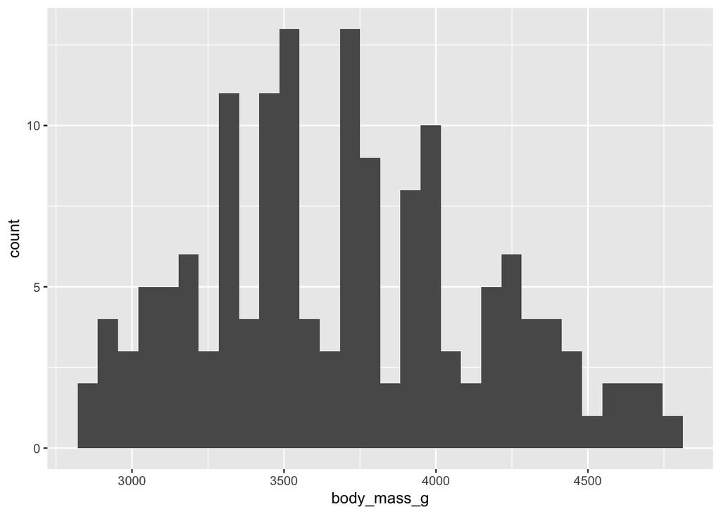

```r
ggplot(data=adelie) +
  geom_histogram(aes(x=body_mass_g))
```

```r
pdf('figures/adelie_body_mass.pdf', width=7, height=5)
ggplot(data=adelie) +
  geom_histogram(aes(x=body_mass_g))
dev.off()
```

```r
mean(adelie$body_mass_g, na.rm=TRUE)
```

```
## [1] 3700.662
```

```r
sd(adelie$body_mass_g, na.rm=TRUE)
```

```
## [1] 458.5661
```

```r
#outlier test
adelie %>%
  identify_outliers(body_mass_g)
```

```
##  [1] species           island            bill_length_mm    bill_depth_mm
##  [5] flipper_length_mm body_mass_g       sex               year
##  [9] is.outlier        is.extreme
## <0 rows> (or 0-length row.names)
```

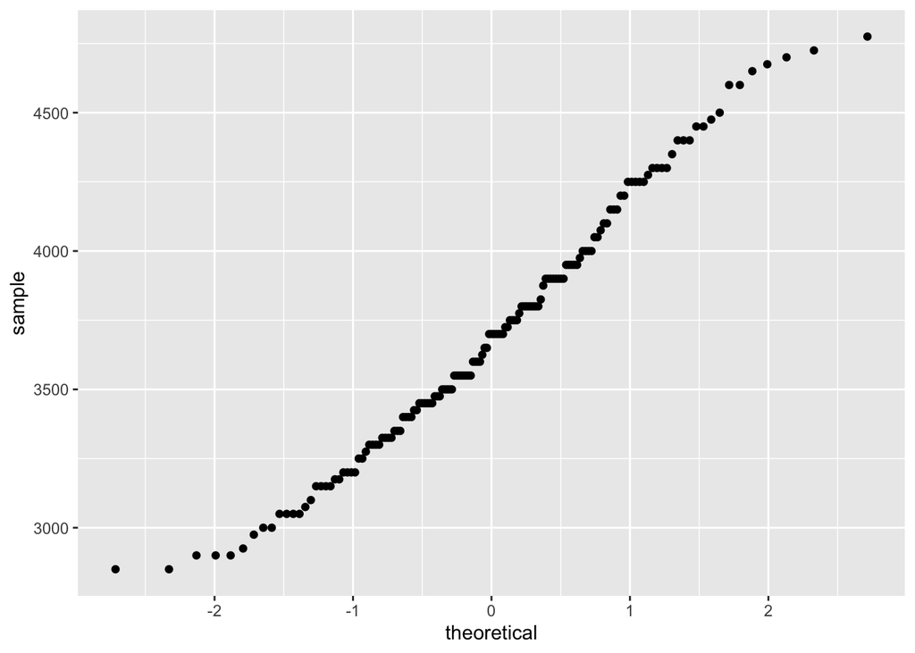

```r
#there are no outliers

# Q-Q plot to check normality assumption
ggplot(data=adelie) +
  stat_qq(aes(sample=body_mass_g))
```

```r
pdf('figures/adelie_qq.pdf', width=7, height=5)
ggplot(data=adelie) +
  stat_qq(aes(sample=body_mass_g))
dev.off()
```

```r
#looks good

#Adelie t-test - used a one sample t-test
t.test(adelie$body_mass_g, mu=4700) # base r version
```

```
##
##  One Sample t-test
##
## data:  adelie$body_mass_g
## t = -26.779, df = 150, p-value < 2.2e-16
## alternative hypothesis: true mean is not equal to 4700
## 95 percent confidence interval:
##  3626.926 3774.398
## sample estimates:
## mean of x
##  3700.662
```

```r
adelie %>%                          #dplyr version
  t_test(body_mass_g ~ 1, mu=4700)
```

```
## # A tibble: 1 x 7
##   .y.         group1 group2         n statistic    df        p
## * <chr>       <chr>  <chr>      <int>     <dbl> <dbl>    <dbl>
## 1 body_mass_g 1      null model   152     -26.8   150 5.06e-59
```

```r
#Effect size
adelie %>% cohens_d(body_mass_g ~ 1, mu = 4700)
```

```
## # A tibble: 1 x 6
##   .y.         group1 group2     effsize     n magnitude
## * <chr>       <chr>  <chr>        <dbl> <int> <ord>
## 1 body_mass_g 1      null model   -2.18   152 large
```

```r
# p =  5.06e-59, effect size = -2.18.
```

I used a one-sample t-test for this analysis because I was comparing one experimental average with one known value. The Adelie body mass was significantly different from the literature, with a p-value of 5.06e-59 and an effect size of -2.18. This is an extremely large effect size, just as we saw in class with the gentoo data. More research is needed to investigate why these two body mass estimates are so different. The Palmer data is much lower than the Encyclopedia of Life estimate, which may mean that penguin size is decreasing since the EOL estimate was taken. However, I personally think more sampling is needed to calculate a more accurate mean body mass for the species, and that the EOL estimate is likely inaccurate.

### Question 2

Are our observations of Chinstrap body mass significantly different from the literature?

```r
chinstrap = penguins %>%
  filter(species == "Chinstrap")
head(chinstrap)
```

```
## # A tibble: 6 x 8
##   species island bill_length_mm bill_depth_mm flipper_length_… body_mass_g sex
##   <fct>   <fct>           <dbl>         <dbl>            <int>       <int> <fct>
## 1 Chinst… Dream            46.5          17.9              192        3500 fema…
## 2 Chinst… Dream            50            19.5              196        3900 male
## 3 Chinst… Dream            51.3          19.2              193        3650 male
## 4 Chinst… Dream            45.4          18.7              188        3525 fema…
## 5 Chinst… Dream            52.7          19.8              197        3725 male
## 6 Chinst… Dream            45.2          17.8              198        3950 fema…
## # … with 1 more variable: year <int>
```

```r
summary(chinstrap)
```

```
##       species         island   bill_length_mm  bill_depth_mm
##  Adelie   : 0   Biscoe   : 0   Min.   :40.90   Min.   :16.40
##  Chinstrap:68   Dream    :68   1st Qu.:46.35   1st Qu.:17.50
##  Gentoo   : 0   Torgersen: 0   Median :49.55   Median :18.45
##                                Mean   :48.83   Mean   :18.42
##                                3rd Qu.:51.08   3rd Qu.:19.40
##                                Max.   :58.00   Max.   :20.80
##  flipper_length_mm  body_mass_g       sex          year
##  Min.   :178.0     Min.   :2700   female:34   Min.   :2007
##  1st Qu.:191.0     1st Qu.:3488   male  :34   1st Qu.:2007
##  Median :196.0     Median :3700               Median :2008
##  Mean   :195.8     Mean   :3733               Mean   :2008
##  3rd Qu.:201.0     3rd Qu.:3950               3rd Qu.:2009
##  Max.   :212.0     Max.   :4800               Max.   :2009
```

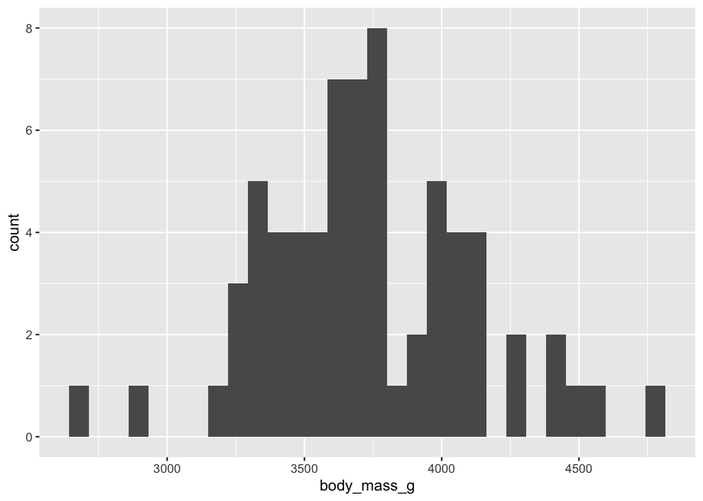

```r
ggplot(data=chinstrap) +
  geom_histogram(aes(x=body_mass_g))
```

```r
pdf('figures/chinstrap_body_mass.pdf', width=7, height=5)
ggplot(data=chinstrap) +
  geom_histogram(aes(x=body_mass_g))
dev.off()
```

```r
mean(chinstrap$body_mass_g, na.rm=TRUE)
```

```
## [1] 3733.088
```

```r
sd(chinstrap$body_mass_g, na.rm=TRUE)
```

```
## [1] 384.3351
```

```r
#outlier test
chinstrap %>%
  identify_outliers(body_mass_g)
```

```
## # A tibble: 2 x 10
##   species island bill_length_mm bill_depth_mm flipper_length_… body_mass_g sex
##   <fct>   <fct>           <dbl>         <dbl>            <int>       <int> <fct>
## 1 Chinst… Dream            52            20.7              210        4800 male
## 2 Chinst… Dream            46.9          16.6              192        2700 fema…
## # … with 3 more variables: year <int>, is.outlier <lgl>, is.extreme <lgl>
```

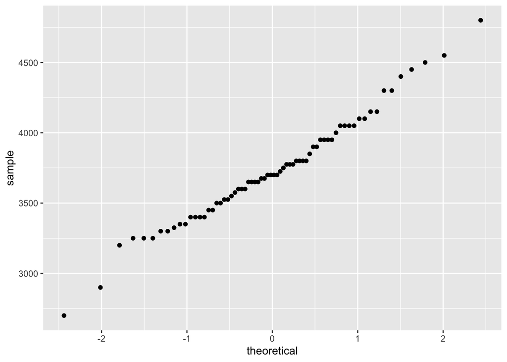

```r
# Q-Q plot to check normality assumption
ggplot(data=chinstrap) +
  stat_qq(aes(sample=body_mass_g))
```

```r
pdf('figures/chinstrap_qq.pdf', width=7, height=5)
ggplot(data=chinstrap) +
  stat_qq(aes(sample=body_mass_g))
dev.off()
```

```r
#Chinstrap t-test - used a one sample t-test; body mass comes from: Sanz, J.J. (1995). Field Metabolic Rates of Breeding Chinstrap Penguins (Pygoscelis antarctica) in the South Shetlands. Physiological Zoology, 69(3), 586-598.

t.test(chinstrap$body_mass_g, mu=3790) # base r version
```

```
##
##  One Sample t-test
##
## data:  chinstrap$body_mass_g
## t = -1.2211, df = 67, p-value = 0.2263
## alternative hypothesis: true mean is not equal to 3790
## 95 percent confidence interval:
##  3640.059 3826.117
## sample estimates:
## mean of x
##  3733.088
```

```r
chinstrap %>%                          #dplyr version
  t_test(body_mass_g ~ 1, mu=3790)
```

```
## # A tibble: 1 x 7
##   .y.         group1 group2         n statistic    df     p
## * <chr>       <chr>  <chr>      <int>     <dbl> <dbl> <dbl>
## 1 body_mass_g 1      null model    68     -1.22    67 0.226
```

```r
#Effect size
chinstrap %>% cohens_d(body_mass_g ~ 1, mu = 3790)
```

```
## # A tibble: 1 x 6
##   .y.         group1 group2     effsize     n magnitude
## * <chr>       <chr>  <chr>        <dbl> <int> <ord>
## 1 body_mass_g 1      null model  -0.148    68 negligible
```

```r
# p = 0.226, effect size = -0.148.
```

Again, I used a one-sample t-test for this analysis because I was comparing one experimental average with one known value. The Chinstrap body mass was not significantly different from the literature, with a p-value of 0.226 and an effect size of -0.148. This is an exciting result, especially given how inaccurate the EOL estimates seem to be. I did my own literature search to find an estimate for chinstrap body mass, and the estimate I found in Sanz’s 1995 paper seems to be very accurate compared with the Palmer series data. The effect size is negligible, thereby giving even more confidence to the result.